# Environment setup, data ingestion, and data cleaning

## Instructions

- Use this notebook to unpack the LMP and capacity price data.
- Make sure to update the `revmpath`, `datapath`, `apikeys`, and `nsrdbparams` variables in `settings.py`.
- Note that ERCOT and ISONE nodes are not publicly accessible and must be requested from ISO representatives.

```python
### Standard imports
import pandas as pd
import numpy as np
import os, sys, site, pickle, json, shutil, shapely, zipfile
import matplotlib.pyplot as plt
import matplotlib as mpl
from glob import glob
from tqdm import tqdm, trange, tnrange, tqdm_notebook
import urllib, googlemaps, requests
import geopandas as gpd

from matplotlib.ticker import (
    AutoMinorLocator, MultipleLocator, AutoLocator, PercentFormatter)
pd.options.display.max_columns = 200
pd.options.display.max_rows = 15
%config InlineBackend.figure_format = 'retina'

### Import the package
### (Note: scriptpath should lead to folder above 'pvvm' folder)
# scriptpath = os.path.expanduser('~/path/to/folder/above/pvvm/')
scriptpath = os.path.expanduser('~/Dropbox/MITEI/Projects/REValueMap/Package/pvtos_FINAL/')
site.addsitedir(scriptpath)
import pvvm

revmpath = pvvm.settings.revmpath
datapath = pvvm.settings.datapath
pvvm.plots.plotparams()
```

# Copy input files

```python
### Make file structure
pvvm.data.makefolders()
```

```python
###### Copy extra input files to data folder
os.makedirs(datapath+'BLS/', exist_ok=True)
shutil.copy(
    scriptpath+'pvvm/data/BLS/inflation_cpi_level.xlsx',
    datapath+'BLS/')
```

```
'/Users/patrickbrown/Desktop/pvvmtest1/Data/BLS/inflation_cpi_level.xlsx'
```

```python
###### Copy results files to output folder
for file in ['results_pvtos_histsun_public.csv.gz', 'results_pvtos_tmyopt_public.csv.gz']:
    shutil.copy(scriptpath+'results/'+file, revmpath+'out/')
```

```python
### IMPORTANT: Change to False for actual operation
test = True
###########

### Copy LMP data and write nodecounts and averages
markets = ['da','rt']
isos = ['CAISO','ERCOT','PJM','NYISO','ISONE']
for market in markets:
    for year in range(2010,2018):
        print(year, market)
        for iso in isos:
            try:
                pvvm.data.copylmps(iso, market, year, test=True)
            except FileNotFoundError:
                print('no data for {} {} {}'.format(iso,market,year))
```

```
2010 da
```

```
no data for ERCOT da 2010
```

```
2011 da
```

```
2012 da
```

```
2013 da
```

```
2014 da
```

```
2015 da
```

```
2016 da
```

```
2017 da
```

```
2010 rt
```

```
no data for ERCOT rt 2010
```

```
no data for ISONE rt 2010
2011 rt
```

```
2012 rt
```

```
2013 rt
```

```
2014 rt
```

```
2015 rt
```

```
2016 rt
```

```
2017 rt
```

# Extract LMP node locations

```python
dfnodes = {}
```

- CAISO node locations are extracted from this map:
  - graphical version: http://www.caiso.com/PriceMap/Pages/default.aspx
  - xml version: http://wwwmobile.caiso.com/Web.Service.Chart/api/v1/ChartService/GetPriceContourMap
- As noted in the function text, first download the xml file and save it at `revmpath + 'CAISO/in/GetPriceContourMap.xml`.

```python
### After downloading the file
dfnodes['CAISO'] = pvvm.data.nodelocations_caiso()
```

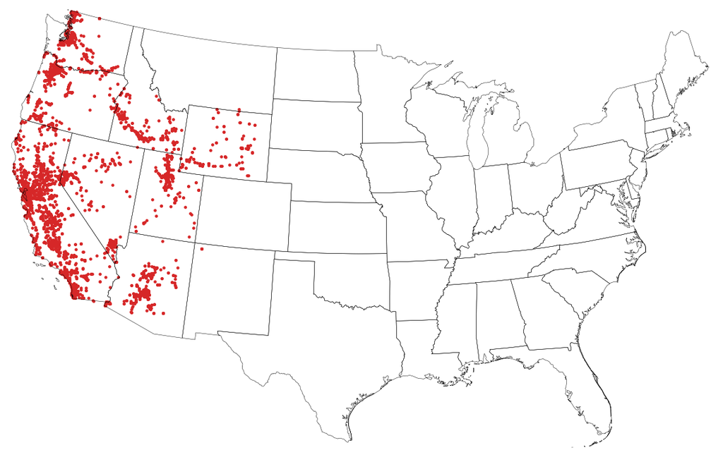

```python
plt.close()
pvvm.plots.plotusascattermap(dfnodes['CAISO'],downloadmap=True)
plt.show()
```

- MISO node locations are extracted automatically from this map:
  - graphical version: https://api.misoenergy.org/MISORTWD/lmpcontourmap.html
  - json version: https://api.misoenergy.org/MISORTWDDataBroker/DataBrokerServices.asmx?messageType=getvectorsource&nodeTypes=GEN,INT,LZN

```python
dfnodes['MISO'] = pvvm.data.nodelocations_miso()
```

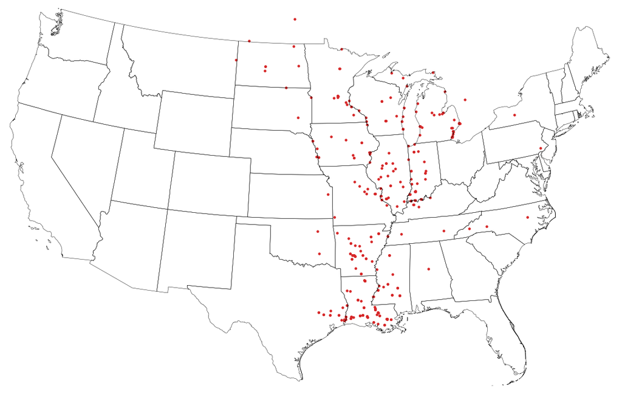

```python
plt.close()
pvvm.plots.plotusascattermap(dfnodes['MISO'])
plt.show()
```

- As described in http://ceepr.mit.edu/publications/working-papers/705, PJM node locations are taken as the centroid of the centers of all zip codes that list that node as the closest node, using this table from PJM: https://www.pjm.com/-/media/markets-ops/energy/lmp-model-info/zip-code-mapping.ashx (parent page at https://www.pjm.com/markets-and-operations/energy/lmp-model-info.aspx)

```python
dfnodes['PJM'] = pvvm.data.nodelocations_pjm()
```

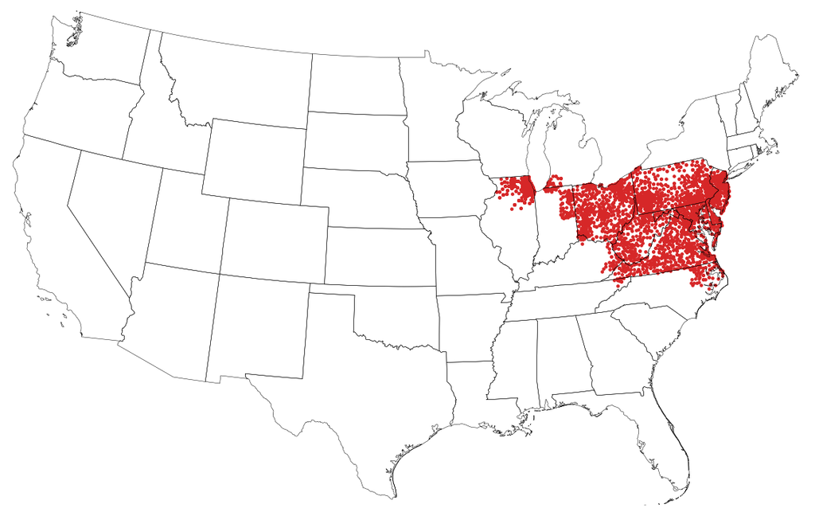

```python
plt.close()
pvvm.plots.plotusascattermap(dfnodes['PJM'])
plt.show()
```

- As described in http://ceepr.mit.edu/publications/working-papers/705, NYISO node locations are determined from the center of googlemaps queries of the cities or counties associated with each node in the "NYCA Generating Facilities" documents available at https://www.nyiso.com/cspp. If multiple cities or counties are associated with a given node, the node location is taken as the centroid of the cities or counties that list it.

```python
dfnodes['NYISO'] = pvvm.data.nodelocations_nyiso()
```

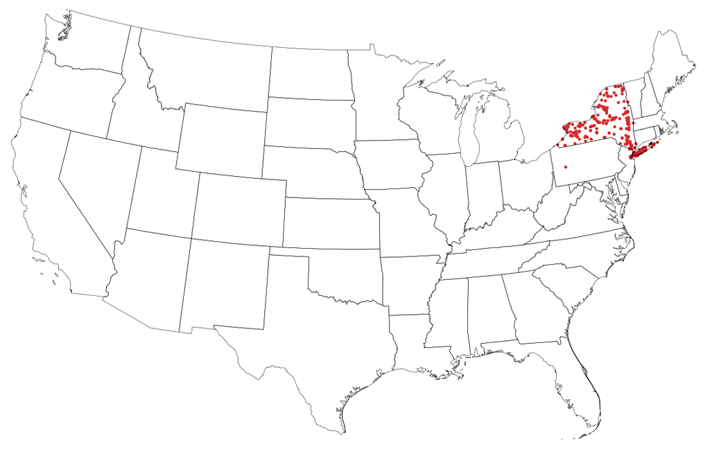

```python
plt.close()
pvvm.plots.plotusascattermap(dfnodes['NYISO'])
plt.show()
```

- ERCOT node locations are extracted from a Monthly CRR Network Model file. Accessing this file requires registering as an "Independent Market Research Entity" at http://www.ercot.com/services/rq/imre and paying the associated fees. Once registered as an IMRE, go to https://mis.ercot.com/pps/tibco/mis/Pages/Grid+Information/Long+Term+Planning, then select 'CRR Network Model (Monthly)'. Download and unzip one of the available files and use the filepath as the input value for filepath_input. Example: `revmpath+'ERCOT/in/rpt.00011205.0000000000000000.20170530.140432154.JUL2017MonthlyCRRNetworkModel/` `2017.JUL.Monthly.Auction.OneLineDiagram.kml'`

```python
### Need to register as ERCOT IMRE to access this file
dfnodes['ERCOT'] = pvvm.data.nodelocations_ercot(
    revmpath+'ERCOT/in/rpt.00011205.0000000000000000.20170530.140432154.JUL2017MonthlyCRRNetworkModel/'
    '2017.JUL.Monthly.Auction.OneLineDiagram.kml')
```

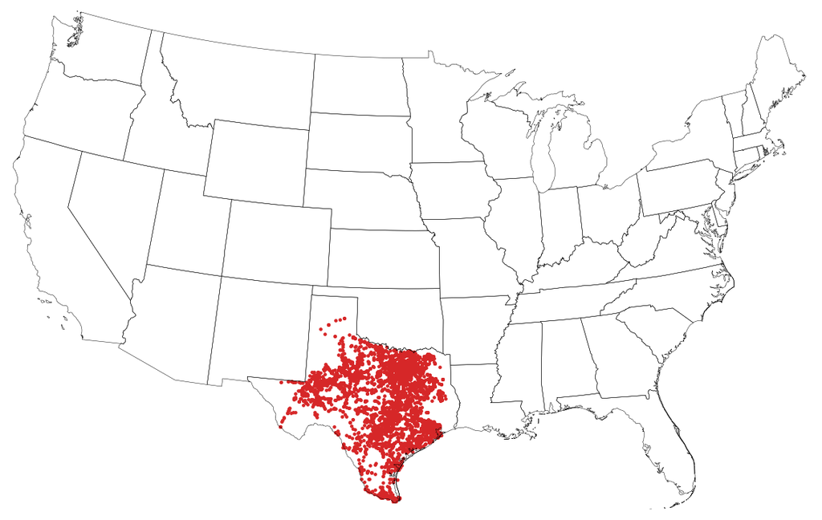

```python
plt.close()
pvvm.plots.plotusascattermap(dfnodes['ERCOT'])
plt.show()
```

- ISONE node locations can be requested from ISONE at https://www.iso-ne.com/participate/support/request-information/

```python
### Need to request this file from ISONE
dfnodes['ISONE'] = pvvm.data.nodelocations_isone(revmpath+'ISONE/in/ne_pnode_lat_long.xlsx')
```

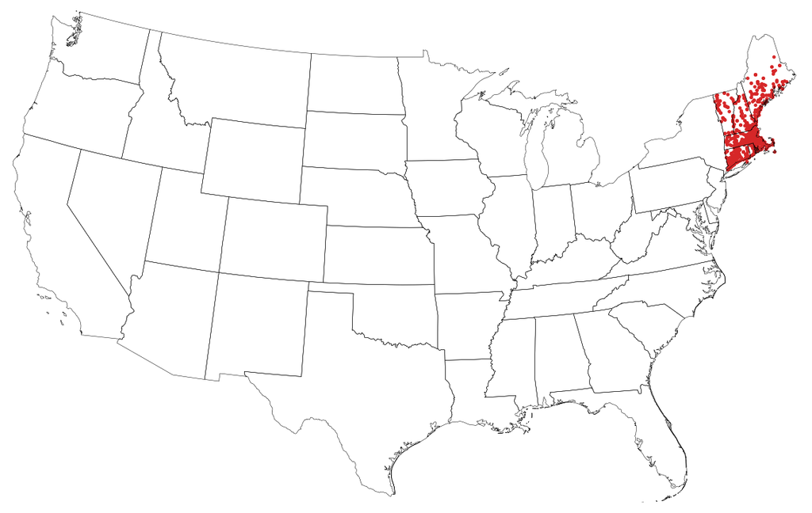

```python
plt.close()
pvvm.plots.plotusascattermap(dfnodes['ISONE'])
plt.show()
```

# Download and work up MISO LMP files as example

## Download

```python
iso = 'MISO'

#############
### Day-ahead
market = 'da'

###### Pre-201503
### Download zipped files
dates = pd.date_range('2010-01-01','2015-02-01',freq='MS')
dates = [date.strftime('%Y%m') for date in dates]
urls = [
    'https://docs.misoenergy.org/marketreports/{}_da_lmp_csv.zip'.format(date)
    for date in dates]
pvvm.data.download_file_series(
    urlstart='', urlend='', fileseries=urls,
    filepath=revmpath+'{}/in/lmp/{}/zip/'.format(iso, market),
    sleeptime=60,
)

### Unzip the monthly-packaged files
dates = pd.date_range('2010-01-01','2015-02-01',freq='MS')
dates = [date.strftime('%Y%m') for date in dates]
filepath = revmpath+'{}/in/lmp/{}/'.format(iso, market)
zipfiles = [filepath+'zip/'+date+'_da_lmp_csv.zip' for date in dates]

for file in zipfiles:
    zip_file = zipfile.ZipFile(file, 'r')
    zip_file.extractall(filepath)
    zip_file.close()
```

```python
###### Post-201503
for year in [2016,2017]:
    pvvm.data.download_lmps(year=year, iso=iso, market=market)

### 2015 - normal procedure only works from 20150301 onward
dates = pd.date_range('2015-03-01','2015-12-31',freq='D')
dates = [date.strftime('%Y%m%d') for date in dates]
urls = [
    'https://docs.misoenergy.org/marketreports/{}_da_expost_lmp.csv'.format(date)
    for date in dates]
pvvm.data.download_file_series(
    urlstart='', urlend='', fileseries=urls,
    filepath=revmpath+'{}/in/lmp/{}/'.format(iso, market),
    sleeptime=60,
)
```

```python
#############
### Real-time
market = 'rt'

###### Pre-2017
### Download zipped files
dates = pd.date_range('2010-01-01','2016-12-01',freq='MS')
dates = [date.strftime('%Y%m') for date in dates]
urls = [
    'https://docs.misoenergy.org/marketreports/{}_rt_lmp_final_csv.zip'.format(date)
    for date in dates]
pvvm.data.download_file_series(
    urlstart='', urlend='', fileseries=urls,
    filepath=revmpath+'{}/in/lmp/{}/zip/'.format(iso, market),
    sleeptime=60,
)

### Unzip the monthly-packaged files
dates = pd.date_range('2010-01-01','2016-12-01',freq='MS')
dates = [date.strftime('%Y%m') for date in dates]
filepath = revmpath+'{}/in/lmp/{}/'.format(iso, market)
zipfiles = [filepath+'zip/'+date+'_rt_lmp_final_csv.zip' for date in dates]

for file in zipfiles:
    zip_file = zipfile.ZipFile(file, 'r')
    zip_file.extractall(filepath)
    zip_file.close()
```

```python
###### Post-2017
pvvm.data.download_lmps(year=2017, iso=iso, market=market)
```

## Nodalize LMP files

Correct daylight savings time, save as one-node full-year files

```python
for market in ['da','rt']:
    for year in range(2010,2018):
        pvvm.data.nodalize(year=year, market=market, iso=iso,)
```

[output not shown]

## Package LMPs into complete dataframes

```python
def lmppackage(iso, year, market='da', inpath=None):
    """
    """
    ### Set and make filepaths
    if (inpath is None) and (market == 'da'):
        inpath = revmpath + iso + '/io/lmp-nodal/{}/'.format(market)
    elif (inpath is None) and (market == 'rt'):
        inpath = {
            'CAISO': revmpath + 'CAISO/io/lmp-nodal/rt/rtm-yearly/',
            'ERCOT': revmpath + 'ERCOT/io/lmp-nodal/rt-year/',
            'MISO':  revmpath + 'MISO/io/lmp-nodal/rt/',
            'PJM':   revmpath + 'PJM/io/lmp-nodal/rt/',
            'NYISO': revmpath + 'NYISO/io/lmp-nodal/rt/',
            'ISONE': revmpath + 'ISONE/io/lmp-nodal/rt/',
        }
        inpath = inpath[iso]

    ### Get the input files
    infiles = glob(inpath+'*{}.gz'.format(year))
    assert len(infiles) > 0, 'no input LMP files found'

    ### Load and concat the input files
    dfs = {}
    for i, file in enumerate(tqdm_notebook(infiles, desc='{} {}'.format(market, year))):
        node = os.path.basename(file)
        node = node[:node.find('-')]
        df = pd.read_csv(file, index_col=0, names=['lmp'], squeeze=True)
        dfs[node] = df

    dflmp = pd.concat(dfs, axis=1, copy=False)

    return dflmp

outpath = datapath+'lmp/'
os.makedirs(outpath, exist_ok=True)

for market in ['da','rt']:
    for year in range(2010,2018):
        dflmp = lmppackage(iso=iso, year=year, market=market)
        dflmp.to_csv(
            '{}{}-lmp-{}-{}.gz'.format(
                outpath,iso.lower(), market, year),
            compression='gzip')
```

# Download NSRDB data

- Run this cell for all years and for 'tmy'

```python
pvvm.data.downloadNSRDBfiles_iso(year=2015)
```

```
CAISO 2015: 6107 done, 329 to download
```

```
ERCOT 2015: 4081 done, 0 to download
MISO 2015: 389 done, 5 to download
```

```
0it [00:00, ?it/s]
0it [00:00, ?it/s]
0it [00:00, ?it/s]
```

```
NYISO 2015: 2362 done, 0 to download
PJM 2015: 2362 done, 0 to download
ISONE 2015: 1087 done, 0 to download
```

```python
# for year in list(range(2010,2018)) + ['tmy']:
#     pvvm.data.downloadNSRDBfiles_iso(year=year)
```

# Characterize input LMP data

### Calculate CA-only CAISO profiles

```python
iso = 'CAISO'
markets = ['da','rt']
years = list(range(2010,2018))

caisonodes = pvvm.data.nodelocations_caiso()
caisonodes = caisonodes.loc[caisonodes.area=='CA','node'].values
for market in markets:
    for year in tqdm_notebook(years, desc=market):
        df = pvvm.io.getdflmp('CAISO',market,year).loc[:,caisonodes].dropna(axis=1)

        ### Write the average files
        meanoutpath = revmpath+iso+'/io/lmp-nodal-mean/'
        os.makedirs(meanoutpath, exist_ok=True)
        df.mean(axis=1).to_csv(
            meanoutpath+'lmp-{}-{}-CAonly-mean.csv'.format(market, year))
        df.median(axis=1).to_csv(
            meanoutpath+'lmp-{}-{}-CAonly-median.csv'.format(market, year))
        percentiles = [0.005, 0.01, 0.025, 0.1, 0.25, 0.5,
                       0.75, 0.9, 0.975, 0.99, 0.995]
        df.T.describe(percentiles=percentiles).T.to_csv(
            meanoutpath+'lmp-{}-{}-CAonly-percentiles.csv'.format(market, year))
```

## LMP profiles

### Hourly average LMPs

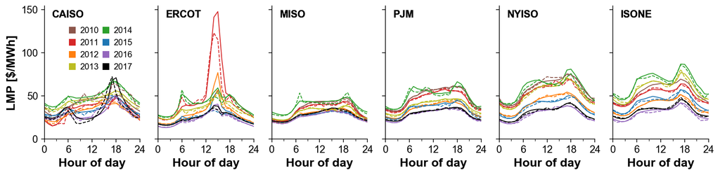

```python
metric = 'mean'
CAonly = True
isos = ['CAISO', 'ERCOT', 'MISO', 'PJM', 'NYISO', 'ISONE']
years = list(range(2010,2018))
# colors = ['C5','C3','C1','C8','C2','C0','C4','k']
colors = pvvm.plots.rainbowmapper(years, plt.cm.coolwarm)
colors = pvvm.plots.rainbowmapper(years)
linestyles = {'da':'-','rt':'--'}
rows, cols = 1, 6

if rows > 1 and cols > 1:
    coords = dict(zip(
        isos, [(row,col) for row in range(rows) for col in range(cols)]))
else:
    coords = dict(zip(isos, range(max([rows,cols]))))

### Plot it
plt.close()
f, ax = plt.subplots(rows, cols, figsize=(cols*2, rows*3),
                     sharex=True, sharey=True)
for market in ['da','rt']:
    for i, iso in enumerate(isos):
        inpath = revmpath + iso + '/io/lmp-nodal-mean/'
        if (iso == 'CAISO') and (CAonly == True):
            infiles = [inpath+'lmp-{}-{}-CAonly-{}.csv'.format(market, year, metric)
                       for year in years]
        elif (iso == 'ERCOT') or ((iso == 'ISONE') and (market == 'rt')):
            infiles = [inpath+'lmp-{}-{}-{}.csv'.format(market, year, metric)
                       for year in years[1:]]
        else:
            infiles = [inpath+'lmp-{}-{}-{}.csv'.format(market, year, metric)
                       for year in years]
        dfs = {}
        for file in infiles:
            year = os.path.basename(file).split('-')
            year = int(year[2])
            if year in years:
                dfs[year] = pd.read_csv(
                    file, index_col=0, names=[year], squeeze=True,
                    parse_dates=True)
        dflmp = pd.concat(dfs, axis=1)

        dflmp.index = (dflmp.index
                       #.tz_localize('UTC')
                       .tz_convert(pvvm.toolbox.tz_iso[iso]))

        dfplot = dflmp.groupby([dflmp.index.hour]).mean()
        ### Correct for inflation # unneccesary since normalizing
        for col in dfplot.columns:
            dfplot[col] = dfplot[col].map(lambda x: x * pvvm.model.inflate(col))
        ### Plot it
        for year in dfplot.columns:
            dfplot[year][len(dfplot)] = dfplot[year].iloc[0] # Loop around to midnight
            (dfplot[year]
#              / dflmp[year].mean()
            ).plot(
                ax=ax[coords[iso]], c=colors[year], lw=1, ls=linestyles[market],
                label=year if market == 'da' else '_nolabel_')

        ax[coords[iso]].annotate(iso, xy=(0.08, 0.97), xycoords='axes fraction',
                                 horizontalalignment='left', verticalalignment='top',
                                 weight='bold', fontsize='large')

### Format axes
ax[0].set_ylabel('LMP [$/MWh]')
ax[0].set_xlim(0,24)
ax[0].set_ylim(0)
for col in range(cols):
    ax[col].xaxis.set_minor_locator(AutoMinorLocator(2))
    ax[col].xaxis.set_major_locator(MultipleLocator(6))
    ax[col].set_xlabel('Hour of day')
    ax[col].tick_params(which='both',right=False,top=False,direction='out') ### CHANGED (direction='out')
    for which in ['right', 'top']:
        ax[col].spines[which].set_visible(False)

### Add the legend
leg1 = ax[coords['CAISO']].legend(
    ncol=2, columnspacing=0.5, frameon=False,
    handletextpad=0.5, handlelength=.8,
    loc='upper right', bbox_to_anchor=(1,.9))
## set the linewidth of each legend object
for legobj in leg1.legendHandles:
    legobj.set_linewidth(8)
    legobj.set_solid_capstyle('butt')

plt.tight_layout()
plt.show()
```

### Hourly average LMPs divided by yearly average LMP

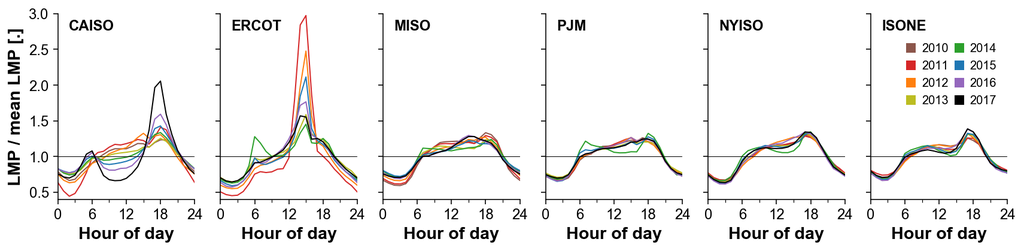

```python
market = 'da'
metric = 'mean'
CAonly = True
isos = ['CAISO', 'ERCOT', 'MISO', 'PJM', 'NYISO', 'ISONE']
years = list(range(2010,2018))
colors = pvvm.plots.rainbowmapper(years)
rows, cols = 1, 6

if rows > 1 and cols > 1:
    coords = dict(zip(
        isos, [(row,col) for row in range(rows) for col in range(cols)]))
else:
    coords = dict(zip(isos, range(max([rows,cols]))))

f, ax = plt.subplots(rows, cols, figsize=(cols*2, rows*3),
                     sharex=True, sharey=True)
for i, iso in enumerate(isos):
    inpath = revmpath + iso + '/io/lmp-nodal-mean/'
    if (iso == 'CAISO') and (CAonly == True):
        infiles = [inpath+'lmp-{}-{}-CAonly-{}.csv'.format(market, year, metric)
                   for year in years]
    elif (iso == 'ERCOT') or ((iso == 'ISONE') and (market == 'rt')):
        infiles = [inpath+'lmp-{}-{}-{}.csv'.format(market, year, metric)
                   for year in years[1:]]
    else:
        infiles = [inpath+'lmp-{}-{}-{}.csv'.format(market, year, metric)
                   for year in years]
    dfs = {}
    for file in infiles:
        year = os.path.basename(file).split('-')
        year = int(year[2])
        if year in years:
            dfs[year] = pd.read_csv(
                file, index_col=0, names=[year], squeeze=True,
                parse_dates=True)
    dflmp = pd.concat(dfs, axis=1)

    dflmp.index = (dflmp.index
                   #.tz_localize('UTC')
                   .tz_convert(pvvm.toolbox.tz_iso[iso]))

    dfplot = dflmp.groupby([dflmp.index.hour]).mean()
    ### Correct for inflation # unneccesary since normalizing
    # for col in dfplot.columns:
    #     dfplot[col] = dfplot[col].map(lambda x: x * pvvm.model.inflate(col))
    ### Plot it
    for year in dfplot.columns:
        dfplot[year][len(dfplot)] = dfplot[year].iloc[0] # Loop around to midnight
        (dfplot[year] / dflmp[year].mean()).plot(
            ax=ax[coords[iso]], c=colors[year], lw=1)

    ax[coords[iso]].annotate(iso, xy=(0.08, 0.97), xycoords='axes fraction',
                             horizontalalignment='left', verticalalignment='top',
                             weight='bold', fontsize='large')

### Format axes
ax[0].set_ylabel('LMP / mean LMP [.]')
ax[0].set_xlim(0,24)
ax[0].set_ylim(0.4, 3)
for col in range(cols):
    ax[col].xaxis.set_minor_locator(AutoMinorLocator(2))
    ax[col].xaxis.set_major_locator(MultipleLocator(6))
    ax[col].axhline(1, c='k', lw=0.5)
    ax[col].set_xlabel('Hour of day')
    ax[col].tick_params(which='both',right=False,top=False,direction='out') ###CHANGED (added 'out')
    for which in ['right', 'top']:
        ax[col].spines[which].set_visible(False)

### Add the legend
leg = ax[coords['ISONE']].legend(
    ncol=2, columnspacing=0.5, frameon=False,
    handletextpad=0.5, handlelength=.8,
    loc='upper right', bbox_to_anchor=(1,.9))
## set the linewidth of each legend object
for legobj in leg.legendHandles:
    legobj.set_linewidth(8)
    legobj.set_solid_capstyle('butt')

plt.tight_layout()
plt.show()
```

### Monthly average LMPs

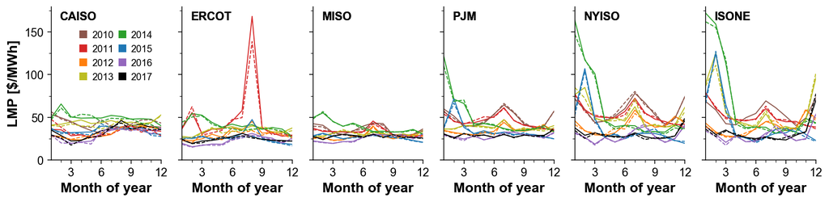

```python
metric = 'mean'
CAonly = True
isos = ['CAISO', 'ERCOT', 'MISO', 'PJM', 'NYISO', 'ISONE']
years = list(range(2010,2018))
linestyles = {'da':'-','rt':'--'}
colors = pvvm.plots.rainbowmapper(years, plt.cm.coolwarm)
colors = pvvm.plots.rainbowmapper(years)
rows, cols = 1, 6

if rows > 1 and cols > 1:
    coords = dict(zip(
        isos, [(row,col) for row in range(rows) for col in range(cols)]))
else:
    coords = dict(zip(isos, range(max([rows,cols]))))

### Plot it
f, ax = plt.subplots(rows, cols, figsize=(cols*2, rows*3),
                     sharex=True, sharey=True)
for i, iso in enumerate(isos):
    for market in ['da','rt']:
        inpath = revmpath + iso + '/io/lmp-nodal-mean/'
        if (iso == 'CAISO') and (CAonly == True):
            infiles = [inpath+'lmp-{}-{}-CAonly-{}.csv'.format(market, year, metric)
                       for year in years]
        elif (iso == 'ERCOT') or ((iso == 'ISONE') and (market == 'rt')):
            infiles = [inpath+'lmp-{}-{}-{}.csv'.format(market, year, metric)
                       for year in years[1:]]
        else:
            infiles = [inpath+'lmp-{}-{}-{}.csv'.format(market, year, metric)
                       for year in years]
        dfs = {}
        for file in infiles:
            year = os.path.basename(file).split('-')
            year = int(year[2])
            if year in years:
                dfs[year] = pd.read_csv(
                    file, index_col=0, names=[year], squeeze=True,
                    parse_dates=True)
        dflmp = pd.concat(dfs, axis=1)

        dflmp.index = (dflmp.index
                       #.tz_localize('UTC')
                       .tz_convert(pvvm.toolbox.tz_iso[iso]))

        dfplot = dflmp.groupby([dflmp.index.month]).mean()
        ### Correct for inflation # unneccesary since normalizing
        for col in dfplot.columns:
            dfplot[col] = dfplot[col].map(lambda x: x * pvvm.model.inflate(col))
        ### Plot it
        for year in dfplot.columns:
    #         dfplot[year][len(dfplot)] = dfplot[year].iloc[0] # Loop around to midnight
            (dfplot[year]
    #          / dflmp[year].mean() ### Uncomment for ratio
            ).plot(
                ax=ax[coords[iso]], c=colors[year], lw=1, ls=linestyles[market],
                label=year if market == 'da' else '_nolabel_')

        ax[coords[iso]].annotate(iso, xy=(0.08, 0.97), xycoords='axes fraction',
                                 horizontalalignment='left', verticalalignment='top',
                                 weight='bold', fontsize='large')

### Format axes
# ax[0].set_ylabel('LMP / mean LMP [.]')
ax[0].set_ylabel('LMP [$/MWh]')
ax[0].set_xlim(1,12)
# ax[0].set_ylim(0.4, 3)
ax[0].set_ylim(0)
for col in range(cols):
    ax[col].xaxis.set_minor_locator(AutoMinorLocator(3))
    ax[col].xaxis.set_major_locator(MultipleLocator(3))
    ax[col].yaxis.set_minor_locator(AutoMinorLocator(2))
#     ax[col].axhline(0, c='k', lw=0.5)
    ax[col].set_xlabel('Month of year')
    ax[col].tick_params(which='both',right=False,top=False,direction='out') ### CHANGED (direction='out')
    for which in ['right', 'top']:
        ax[col].spines[which].set_visible(False)

### Add the legend
leg1 = ax[coords['CAISO']].legend(
    ncol=2, columnspacing=0.5, frameon=False,
    handletextpad=0.5, handlelength=.8,
    loc='upper right', bbox_to_anchor=(1,.9))
## set the linewidth of each legend object
for legobj in leg1.legendHandles:
    legobj.set_linewidth(8)
    legobj.set_solid_capstyle('butt')

plt.tight_layout()

plt.show()
```

## Negative LMPs

### Yearly

```python
# inpath = revmpath+'Package/pvvm/data/lmp/'
inpath = datapath+'lmp/'
years = list(range(2010,2018))
isos = ['CAISO','ERCOT','MISO','PJM','NYISO','ISONE']
resolutions = {
    'da': dict(zip(isos, 6*[60])),
    'rt': {'CAISO':5,'ERCOT':5,'MISO':60,'PJM':60,'NYISO':5,'ISONE':60}
}
percentiles = [0.025, 0.25, 0.75, 0.975]

###### Only nodes with geographic information
dictgeo = {}
for market in ['da','rt']:
    # for iso in ['NYISO','PJM']:
    for iso in isos:
        resolution = resolutions[market][iso]

        ### Get the geo nodes
        dfnodes = pvvm.io.get_iso_nodes(iso)
        if iso == 'CAISO':
            nodes = dfnodes.loc[dfnodes.area=='CA','node'].astype(str).tolist()
        else:
            nodes = dfnodes['node'].astype(str).tolist()

        for year in tqdm_notebook(years, desc='{} {}'.format(market,iso)):
            infile = inpath+'{}-lmp-{}-{}.gz'.format(iso.lower(), market, year)
            try:
                df = pd.read_csv(
                    infile, index_col=0, parse_dates=True,
                ).tz_convert(pvvm.toolbox.tz_iso[iso])
                ### Get the shared nodes
                datanodes = [node for node in df.columns.astype(str).tolist() if node in nodes]
                ### Calculate number of negative intervals for each node,
                ### and describe trends across all nodes
                dictgeo[market, iso, year] = (
                    (df[datanodes] < 0).astype(int).sum(axis=0)
                    / pvvm.toolbox.yearhours(year) / (60 / resolution)
                )
            except FileNotFoundError:
                print(infile)

dffull = pd.concat(dictgeo).reset_index().rename(
    columns={'level_0':'market','level_1':'ISOwecc','level_2':'year','level_3':'node',0:'negative'}
)
```

```
/Users/patrickbrown/Desktop/pvvmtest/Data/lmp/ercot-lmp-da-2010.gz
```

```
/Users/patrickbrown/Desktop/pvvmtest/Data/lmp/ercot-lmp-rt-2010.gz
```

```
/Users/patrickbrown/Desktop/pvvmtest/Data/lmp/isone-lmp-rt-2010.gz
```

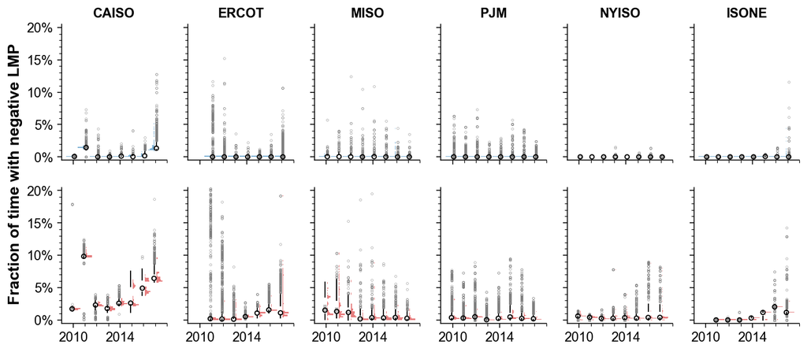

```python
isos = ['CAISO', 'ERCOT', 'MISO', 'PJM', 'NYISO', 'ISONE']
colors = {'da':'C0','rt':'C3'}
plt.close()
f,ax = plt.subplots(2,6,sharey=True,sharex=True,figsize=(12,5))
for row, market in enumerate(['da','rt']):
    for col, iso in enumerate(isos):
        dfframe= dffull.loc[(dffull.ISOwecc==iso)&(dffull.market==market)].pivot(
            index='node',columns='year',values='negative')*100
        pvvm.plots.plotquarthist(ax[row,col], dfframe, bootstrap=5000, density=True, squeeze=0.5,
                                 histcolor=colors[market], alpha=0.6,
                                 direction='left' if market == 'da' else 'right',
                                 histpad=-0.1 if market == 'da' else 0.1,
                                 quartpad=0.1 if market == 'da' else -0.1)
        ### Formatting
        ax[0,col].set_title(iso, weight='bold')
        ax[row,col].yaxis.set_major_formatter(mpl.ticker.PercentFormatter(decimals=0))
#         ax[row,0].annotate('Day-ahead' if market == 'da' else 'Real-time',
#                            xy=(0.05,0.97), xycoords='axes fraction',
#                            ha='left', va='top', size='large')
        ax[row,col].yaxis.set_minor_locator(AutoMinorLocator(5))
        ### Rotate labels
        ax[(row,col)].set_xticks([2010,2014])
        ax[(row,col)].set_xticklabels(
            ['2010','2014'], rotation=0, ha='center')
        ax[(row,col)].xaxis.set_minor_locator(AutoMinorLocator(4))
        ax[(row,col)].set_xlim(2009,2018)


### Formatting
pvvm.plots.despine(ax)
ax[0,0].set_ylabel('Fraction of time with negative LMP', y=-0.1)
ax[0,0].set_ylim(-0.5,20.5)

plt.show()
```

### Hourly

```python
###### Only nodes with geographic information
dicthourly = {}
for market in ['da','rt']:
    # for iso in ['NYISO','PJM']:
    for iso in isos:
        resolution = resolutions[market][iso]

        ### Get the geo nodes
        dfnodes = pvvm.io.get_iso_nodes(iso)
        if iso == 'CAISO':
            nodes = dfnodes.loc[dfnodes.area=='CA','node'].astype(str).tolist()
        else:
            nodes = dfnodes['node'].astype(str).tolist()

        for year in tqdm_notebook(years, desc='{} {}'.format(market,iso)):
            infile = inpath+'{}-lmp-{}-{}.gz'.format(iso.lower(), market, year)
            try:
                df = pd.read_csv(
                    infile, index_col=0, parse_dates=True,
                ).tz_convert(pvvm.toolbox.tz_iso[iso])
                ### Get the shared nodes
                datanodes = [node for node in df.columns.astype(str).tolist() if node in nodes]
                ### Calculate number of negative intervals for each node,
                ### and describe trends across all nodes
                dicthourly[market, iso, year] = (
                    (df[datanodes] < 0).astype(int).groupby(df.index.hour).sum()
                    / pvvm.toolbox.yearhours(year) / (60 / resolution) * 24
                ).T.describe(percentiles=percentiles)
            except FileNotFoundError:
                print(infile)

dfhourly = pd.concat(dicthourly)
dfhourly[24] = dfhourly[0].copy()

dfplot = pd.DataFrame(dfhourly).reset_index().rename(
    columns={'level_0':'market','level_1':'ISO','level_2':'year','level_3':'stat',}
)

dfplot['datum'] = dfplot.market + '_' + dfplot.ISO + '_' + dfplot.year.astype(str)
```

```
/Users/patrickbrown/Desktop/pvvmtest/Data/lmp/ercot-lmp-da-2010.gz
```

```
/Users/patrickbrown/Desktop/pvvmtest/Data/lmp/ercot-lmp-rt-2010.gz
```

```
/Users/patrickbrown/Desktop/pvvmtest/Data/lmp/isone-lmp-rt-2010.gz
```

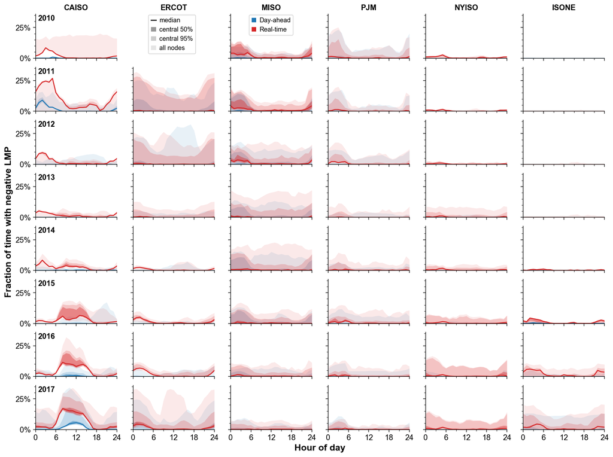

```python
hours = range(25)
markets = ['da','rt']

plt.close()
### Original figsize: 16,10
### New figsize: 16,12
f,ax=plt.subplots(len(years), len(isos), sharex=True, sharey=True, figsize=(16,12))
for col, iso in enumerate(isos):
    for market in markets:
        for row, year in enumerate(years):
            if ((iso == 'ERCOT') and (year == 2010)
                or (iso == 'ISONE') and (year == 2010) and (market == 'rt')
               ):
                if iso == 'ERCOT': ax[(row,col)].axis('off')
                continue
            pvvm.plots.plotquartiles(
                ax=ax[row,col],
                dfdescribe=dfhourly.loc[(market,iso,year)]*100,
                color=colors[market], labels=(True if market=='da' else False)
            )
            ax[row,col].patch.set_facecolor('none')
            # ax[row,0].set_ylabel(year)#, rotation=0, va='top')
    ax[0,col].set_title(iso, weight='bold')
for row, year in enumerate(years):
    ax[row,0].annotate(year, (0.03,0.98), xycoords='axes fraction',
                       ha='left', va='top', weight='bold', fontsize='large')
ax[0,0].xaxis.set_major_locator(MultipleLocator(6))
ax[0,0].xaxis.set_minor_locator(AutoMinorLocator(2))
ax[0,0].set_xlim(0,24)
ax[0,0].set_ylim(0,36)
ax[0,0].yaxis.set_major_locator(MultipleLocator(25))
ax[0,0].yaxis.set_minor_locator(AutoMinorLocator(5))
ax[0,0].yaxis.set_major_formatter(mpl.ticker.PercentFormatter(decimals=0))
ax[-1,2].set_xlabel('Hour of day', x=1.1)
ax[3,0].set_ylabel('Fraction of time with negative LMP', y=-0.1)
# ax[3,0].set_ylabel('Fraction of days with negative LMP', y=-0.1)
### First legend (quartiles)
leg = ax[0,0].legend(loc='upper center', bbox_to_anchor=(1.68,1.05), frameon=True,
                     handletextpad=0.5, handlelength=.8,)
for legobj in leg.legendHandles:
    legobj.set_color('k')
pvvm.plots.despine(ax)
### Second legend (market)
patches = [
    mpl.patches.Patch(
        facecolor=colors[market], edgecolor='none',
        label=('Day-ahead' if market == 'da' else 'Real-time'))
    for market in ['da','rt']]
leg = ax[(0,2)].legend(
    handles=patches, loc='upper center', bbox_to_anchor=(0.5,1.05), frameon=True,
    ncol=1, columnspacing=0.5, handletextpad=0.5, handlelength=0.7,)

plt.show()
```